# Tarea 13 y 14_Ricardo Zamora Mennigke_Mineria de Datos I

Ricardo Zamora Mennigke

7/3/2020

Tarea 13 y 14 Mineria de Datos I Ricardo Zamora Mennigke

```r
library(stringr)
library(rvest)
library(dplyr)
```

```r
library(ggplot2)
library(readxl)
#library(tidyverse)
library(lubridate)
```

1. [8 puntos] Explique en lenguaje natural el significado de cada una de las siguientes expresiones regulares y realice un ejemplo.
1. \d{1,2}-\d{1,2}-\d{4} Sirve para extraer digitos que coincide entre 1 y 2 dos veces el digito de 0 al 9 seguido por un guion luego de nuevo digitos que coincide entre 1 y 2 dos veces el digito de 0 al 9 seguido por un guion, y finalmente extraer digitos que coincide 4 veces el digito de 0 al 9 seguido. Esto segun el formato costarricense puede correponder a un numero de telefono. Ejemplo: 88-11-5555

```r
texto <- 'el telefono es 88-11-5555'
patrones <- str_view_all(texto, pattern = "\\d{1,2}-\\d{1,2}-\\d{4}")
patrones
```

[interactive chart not shown]

2. \w+\@ \w+ \. com caracteres alfanumericos antes de @ y despues de un especio caracteres alfanumericos con .com al final separado con un espacio. Es decir, extrae correos electronicos, pero con espacios. Dado que presenta espacios tiene ciertas diferencias respecto a un correo comun. Ejemplo: info@ oldemarrodriguez . com

```r
texto <- 'el correo electronico del profesor es a.1-2-3  info@ oldemarrodriguez . com  wikipedia.com'
patrones <- str_view_all(texto, pattern = "\\w+\\@ \\w+ \\. com")
patrones
```

[interactive chart not shown]

3. [A − Z][a − z] + (\s[A − Z][a − z]+)∗ Indica letras mayusculas seguida por letras minusculas en patron de espaciado seguidas de letra mayuscula y minuscula en un patron. Esto puede ser un nombre con apellidos aunque no se limita unicamente a ello. Ejemplo: Oldemar Rodriguez

```r
texto <- 'el correo electronico del profesor Oldemar Rodriguez es a.1-2-3  info@ oldemarrodriguez . com  wikipedia.com'
patrones <- str_view_all(texto, pattern = "[A−Z][a−z]+(\\s[A−Z][a−z]+)∗")
patrones
```

[interactive chart not shown]

4. \-?\d+(\,\d+)? Signo guion con patron 0 o 1 vez, seguido de digitos, luego una coma y de nuevo digitos. Podria ser una cifra con decimales y puede ser negativo, en general puede esperarse un digito. Ejemplo: -100,1

```r
texto <- 'El profesor resta -100,1 a 5039'
patrones <- str_view_all(texto, pattern = "\\-?\\d+(\\,\\d+)?")
patrones
```

[interactive chart not shown]

2. [12 puntos] Con la funci´on str_view_all y utilizando como base el texto que se muestra a continuaci´on cree una sola expresi´on regular que permita extraer todos los patrones marcados en el texto.

```r
texto <- 'Tenemos una serie de numeros 9 , 1 y 2 , debe extraerlos, aunque extraer n´umeros sueltos puede ser demasiado sencillo para un ejercicio, veamos que pasa si agregamos decimales por ejemplo 9.2 o 320.4 y hasta, por que no, 3.14159265359 , podemos tambi´en usar el signo de ’coma’ para separar los miles por ejemplo 3,450 o 2,981,009.21 aunque hay personas que prefieren utilizar el espacio en blanco para los miles, aunque esto aveces pueda causar problemas, por ejemplo, 9 822 067 o 5 129 .'
```

```r
patrones <- str_view_all(texto, pattern = "\\d+(.\\d+)*")
patrones
```

[interactive chart not shown]

3. [20 puntos] Una empresa de paraguas utiliza excel para llevar el control de las ventas realizadas cada mes, cada una de las tiendas administra de forma independiente su informaci´on, la due˜na de la empresa solicita un reporte de las ventas, pero identifican que existe una gran cantidad de inconsistencias entre los archivos de cada tienda, utilizando expresiones regulares y su conocimiento en manipulaci´on de datos realice lo siguiente.
1. [2 puntos] Con la ayuda del paquete readxl cargue cada uno de los siguientes archivos ventas_heredia.xlsx, ventas_san_pedro.xlsx, ventas_cartago.xlsx y ventas_jaco.xlsx. Para ello puede guiarse del siguiente c´odigo: > readxl::read_excel(“ruta del archivo”)

```r
setwd("C:/Users/rzamoram/OneDrive - Intel Corporation/Documents/Machine Learning/Mineria de Datos I/Tarea 13 y 14")
heredia <- readxl::read_excel("C:/Users/rzamoram/OneDrive - Intel Corporation/Documents/Machine Learning/Mineria de Datos I/Tarea 13 y 14/ventas_heredia.xlsx")
head(heredia)
```

```
## # A tibble: 6 x 7
##   fecha   vendedor     producto descripcion               cantidad  precio total
##   <chr>   <chr>        <chr>    <chr>                     <chr>     <chr>  <chr>
## 1 01/01/~ maria acosta A16      paraguas playa metalico ~ 1 unidad  10,000 10,0~
## 2 04/01/~ arturo muri~ A18      paraguas playa bamboo bl~ 4  unida~ 17,000 68,0~
## 3 05/01/~ pedro jimen~ A90      Paraguas playa metalico ~ 2  unida~ 20,000 40,0~
## 4 05/01/~ pedro jimen~ SP004    Paraguas colores bamboo   1 unidad  12,000 12,0~
## 5 08/01/~ ana loria    SP003    Paraguas negro metalico   1 unidad  8,500  8,500
## 6 09/01/~ arturo muri~ SP003    Paraguas negro metalico   1 unidad  8,500  8,500
```

```r
sanpedro <- readxl::read_excel("C:/Users/rzamoram/OneDrive - Intel Corporation/Documents/Machine Learning/Mineria de Datos I/Tarea 13 y 14/ventas_san_pedro.xlsx")
head(sanpedro)
```

```
## # A tibble: 6 x 7
##   fecha   vendedor     producto descripcion                cantidad precio total
##   <chr>   <chr>        <chr>    <chr>                      <chr>    <chr>  <chr>
## 1 02-01-~ marcos solis A90      Paraguas playa metalico c~ 1 Ud.    20 000 20 0~
## 2 07-01-~ pamale guev~ SP004    Paraguas colores bamboo    1 Ud.    12 000 12 0~
## 3 11-01-~ marco lopez  A16      paraguas playa metalico c~ 1 Ud.    10 000 10 0~
## 4 12-01-~ pamale guev~ A18      paraguas playa bamboo bla~ 2  Uds.  17 000 34 0~
## 5 12-01-~ marcos solis SP009    Paraguas colores plastico  1 Ud.    5 500  5 500
## 6 13-01-~ pamale guev~ SP004    Paraguas colores bamboo    2  Uds.  12 000 24 0~
```

```r
cartago <- readxl::read_excel("C:/Users/rzamoram/OneDrive - Intel Corporation/Documents/Machine Learning/Mineria de Datos I/Tarea 13 y 14/ventas_cartago.xlsx")
head(cartago)
```

```
## # A tibble: 6 x 7
##   fecha   vendedor      producto descripcion               cantidad precio total
##   <chr>   <chr>         <chr>    <chr>                     <chr>    <chr>  <chr>
## 1 01-03-~ carlos romero SP009    Paraguas colores plastico 1        5500   5500
## 2 01-06-~ sofia elizon~ A90      Paraguas playa metalico ~ 1        20000  20000
## 3 01-06-~ carlos romero SP003    Paraguas negro metalico   1        8500   8500
## 4 01-07-~ stephany gri~ SP003    Paraguas negro metalico   1        8500   8500
## 5 01-11-~ carlos romero SP004    Paraguas colores bamboo   4        12000  48000
## 6 01-16-~ stephany gri~ SP003    Paraguas negro metalico   1        8500   8500
```

```r
jaco <- readxl::read_excel("C:/Users/rzamoram/OneDrive - Intel Corporation/Documents/Machine Learning/Mineria de Datos I/Tarea 13 y 14/ventas_jaco.xlsx")
head(jaco)
```

```
## # A tibble: 6 x 7
##   fecha        vendedor   producto descripcion             cantidad precio total
##   <chr>        <chr>      <chr>    <chr>                   <chr>    <chr>  <chr>
## 1 01 de enero~ angel mar~ A16      paraguas playa metalic~ 2        10000  20000
## 2 04 de enero~ lalo flor~ SP009    Paraguas colores plast~ 1        5500   5500
## 3 05 de enero~ memo esca~ A90      Paraguas playa metalic~ 1        20000  20000
## 4 05 de enero~ lalo flor~ A16      paraguas playa metalic~ 4        10000  40000
## 5 06 de enero~ lalo flor~ A90      Paraguas playa metalic~ 1        20000  20000
## 6 07 de enero~ angel mar~ A16      paraguas playa metalic~ 4        10000  40000
```

2. [6 puntos] Utilizando expresiones regulares resuelva cada una de las inconsistencias presentes en cada uno de los archivos. Adem´as, para cada una de las tablas de datos agregue una variable con el nombre de la regi´on.

```r
heredia$cantidad <- str_extract(heredia$cantidad, pattern = "\\d+")
head(heredia$cantidad)
```

```
## [1] "1" "4" "2" "1" "1" "1"
```

```r
sanpedro$cantidad <- str_extract(sanpedro$cantidad, pattern = "\\d+")
head(sanpedro$cantidad)
```

```
## [1] "1" "1" "1" "2" "1" "2"
```

```r
cartago$cantidad <- str_extract(cartago$cantidad, pattern = "\\d+")
head(cartago$cantidad)
```

```
## [1] "1" "1" "1" "1" "4" "1"
```

```r
jaco$cantidad <- str_extract(jaco$cantidad, pattern = "\\d+")
head(jaco$cantidad)
```

```
## [1] "2" "1" "1" "4" "1" "4"
```

```r
heredia$cantidad <- str_remove_all(heredia$cantidad, pattern = "[[:blank:]]")
heredia$cantidad <- as.numeric(heredia$cantidad)
head(heredia$cantidad)
```

```
## [1] 1 4 2 1 1 1
```

```r
sanpedro$cantidad <- str_remove_all(sanpedro$cantidad, pattern = "[[:blank:]]")
sanpedro$cantidad <- as.numeric(sanpedro$cantidad)
head(sanpedro$cantidad)
```

```
## [1] 1 1 1 2 1 2
```

```r
cartago$cantidad <- str_remove_all(cartago$cantidad, pattern = "[[:blank:]]")
cartago$cantidad <- as.numeric(cartago$cantidad)
head(cartago$cantidad)
```

```
## [1] 1 1 1 1 4 1
```

```r
jaco$cantidad <- str_remove_all(jaco$cantidad, pattern = "[[:blank:]]")
jaco$cantidad <- as.numeric(jaco$cantidad)
head(jaco$cantidad)
```

```
## [1] 2 1 1 4 1 4
```

```r
heredia$precio <- str_remove_all(heredia$precio, pattern = ",")
heredia$precio <- as.numeric(heredia$precio)
head(heredia$precio)
```

```
## [1] 10000 17000 20000 12000  8500  8500
```

```r
as.numeric(sanpedro$precio)
```

```
##   [1] NA NA NA NA NA NA NA NA NA NA NA NA NA NA NA NA NA NA NA NA NA NA NA NA NA
##  [26] NA NA NA NA NA NA NA NA NA NA NA NA NA NA NA NA NA NA NA NA NA NA NA NA NA
##  [51] NA NA NA NA NA NA NA NA NA NA NA NA NA NA NA NA NA NA NA NA NA NA NA NA NA
##  [76] NA NA NA NA NA NA NA NA NA NA NA NA NA NA NA NA NA NA NA NA NA NA NA NA NA
## [101] NA NA NA NA NA NA NA NA NA NA NA NA NA NA NA NA NA NA NA NA NA NA NA NA NA
## [126] NA NA NA NA NA NA NA NA NA NA NA NA NA NA NA NA NA NA NA NA NA NA NA NA NA
## [151] NA NA NA NA NA NA NA NA NA NA NA NA NA NA NA NA NA NA NA NA NA NA NA NA NA
## [176] NA NA NA NA NA NA NA NA NA NA NA NA NA NA NA NA NA NA NA NA NA NA NA NA NA
```

```r
sanpedro$precio <- str_remove_all(sanpedro$precio, pattern = "[[:blank:]]")
sanpedro$precio <- as.numeric(sanpedro$precio)
head(sanpedro$precio)
```

```
## [1] 20000 12000 10000 17000  5500 12000
```

```r
as.numeric(cartago$precio)
```

```
##   [1]  5500 20000  8500  8500 12000  8500  5500 20000 10000 20000  8500  8500
##  [13] 20000 10000  8500 17000  5500 10000  8500 17000 10000 20000  8500 10000
##  [25] 10000 20000 20000 12000 10000  8500  8500  8500 20000 17000  5500 17000
##  [37]  8500 17000 10000 20000  5500 12000  8500  8500 17000 10000 12000 20000
##  [49]  8500 10000  5500 12000  8500 10000 12000 17000  5500 20000 12000 10000
##  [61] 20000 17000 17000 20000  5500 12000 10000  8500 12000 20000  5500  5500
##  [73] 10000 20000  5500  8500  5500  8500  8500 20000 12000  8500 10000 17000
##  [85] 12000 10000 10000  8500 12000  8500  5500  5500 10000  8500 10000 10000
##  [97] 17000 12000 20000 17000 20000  5500 20000 17000  8500 20000  8500  5500
## [109] 10000  5500 20000  5500  8500 12000 17000 12000  5500 10000  8500 10000
## [121] 12000 17000  5500 12000 12000 20000 12000  5500 10000 17000  5500  5500
## [133] 17000 12000 12000 20000  5500  5500  8500  5500 20000 17000  5500 10000
## [145]  8500 10000 17000  8500 12000 10000 20000 20000  8500 20000  5500  5500
## [157] 10000 20000 20000 10000 10000 17000 12000 20000 20000 17000  8500  5500
## [169] 10000  5500  5500 17000 12000 20000 17000 17000 12000 12000  8500 10000
## [181] 17000  5500 10000 17000  8500 20000  8500 20000  8500 12000 20000 20000
## [193]  8500 17000 17000 10000  5500 17000  5500  5500
```

```r
cartago$precio <- str_remove_all(cartago$precio, pattern = "[[:blank:]]")
cartago$precio <- as.numeric(cartago$precio)
head(cartago$precio)
```

```
## [1]  5500 20000  8500  8500 12000  8500
```

```r
as.numeric(jaco$precio)
```

```
##   [1] 10000  5500 20000 10000 20000 10000 20000  5500 10000  8500  8500 20000
##  [13]  5500  5500  5500  5500  8500  8500  5500  5500  5500 12000 17000 17000
##  [25]  8500 10000 10000 20000 12000  8500 10000 10000 10000  8500  5500 17000
##  [37] 12000 20000  5500  5500 12000  8500 12000  5500 17000  8500 12000  5500
##  [49] 10000  8500 12000 12000 12000  5500 10000 10000 20000  5500 17000 12000
##  [61] 10000 10000  8500 20000 17000 12000  5500 20000  8500 20000 10000 17000
##  [73]  8500 12000  5500  8500 17000 17000  8500 20000 10000  5500  8500 10000
##  [85] 12000  8500  5500 10000 10000 12000 12000  5500  8500  8500 10000 10000
##  [97]  8500 17000 12000  5500 20000  8500  8500 20000 17000 12000 12000  8500
## [109] 17000 20000 17000 17000 20000 17000 17000 12000 10000 12000  5500 12000
## [121] 10000 17000 12000  8500 17000 20000  5500  8500 12000 12000  5500 17000
## [133] 10000 17000  5500  5500 12000  8500 10000 10000  8500 20000 10000 20000
## [145]  5500  5500 17000  8500 10000  8500  8500  5500 17000 20000 12000  5500
## [157] 12000 17000 12000 17000 20000 17000 10000  5500 20000 17000  8500  5500
## [169] 20000 10000 20000 10000  5500 20000 20000 17000 20000  8500  8500 20000
## [181] 17000 12000 17000 10000 12000  8500 12000 20000 17000 20000  8500  5500
## [193] 20000  5500 20000 17000  8500 17000 12000 20000
```

```r
jaco$precio <- str_remove_all(jaco$precio, pattern = "[[:blank:]]")
jaco$precio <- as.numeric(jaco$precio)
head(jaco$precio)
```

```
## [1] 10000  5500 20000 10000 20000 10000
```

```r
heredia$total <- str_remove_all(heredia$total, pattern = ",")
heredia$total <- as.numeric(heredia$total)
head(heredia$total)
```

```
## [1] 10000 68000 40000 12000  8500  8500
```

```r
as.numeric(sanpedro$total)
```

```
##   [1] NA NA NA NA NA NA NA NA NA NA NA NA NA NA NA NA NA NA NA NA NA NA NA NA NA
##  [26] NA NA NA NA NA NA NA NA NA NA NA NA NA NA NA NA NA NA NA NA NA NA NA NA NA
##  [51] NA NA NA NA NA NA NA NA NA NA NA NA NA NA NA NA NA NA NA NA NA NA NA NA NA
##  [76] NA NA NA NA NA NA NA NA NA NA NA NA NA NA NA NA NA NA NA NA NA NA NA NA NA
## [101] NA NA NA NA NA NA NA NA NA NA NA NA NA NA NA NA NA NA NA NA NA NA NA NA NA
## [126] NA NA NA NA NA NA NA NA NA NA NA NA NA NA NA NA NA NA NA NA NA NA NA NA NA
## [151] NA NA NA NA NA NA NA NA NA NA NA NA NA NA NA NA NA NA NA NA NA NA NA NA NA
## [176] NA NA NA NA NA NA NA NA NA NA NA NA NA NA NA NA NA NA NA NA NA NA NA NA NA
```

```r
sanpedro$total <- str_remove_all(sanpedro$total, pattern = "[[:blank:]]")
sanpedro$total <- as.numeric(sanpedro$total)
head(sanpedro$total)
```

```
## [1] 20000 12000 10000 34000  5500 24000
```

```r
as.numeric(cartago$total)
```

```
##   [1]   5500  20000   8500   8500  48000   8500  11000  20000  10000  20000
##  [11]   8500   8500  20000  10000   8500  51000   5500  10000   8500  17000
##  [21]  10000  20000   8500  10000  10000  20000  20000  12000  30000  42500
##  [31]   8500   8500  20000  17000  16500  17000   8500  17000  10000  40000
##  [41]  11000  12000  25500   8500  17000  10000  12000  20000   8500  10000
##  [51]   5500  36000  25500  10000  12000  17000   5500  20000  24000  10000
##  [61]  20000  51000  17000  20000   5500  24000  10000   8500  12000  20000
##  [71]   5500   5500  10000  20000  16500   8500   5500   8500  17000  40000
##  [81]  12000  17000  20000  68000  36000  10000  30000   8500  12000   8500
##  [91]   5500   5500  10000   8500  40000  10000  17000  12000  20000  17000
## [101]  20000   5500  20000  17000   8500  60000   8500   5500  10000   5500
## [111]  20000   5500   8500  12000  17000  60000   5500  10000  17000  10000
## [121]  12000  17000   5500  36000  12000  20000  12000   5500  10000  17000
## [131]   5500   5500  17000  12000  24000 100000   5500   5500   8500   5500
## [141]  20000  17000   5500  10000   8500  10000  17000   8500  12000  10000
## [151]  20000  20000   8500  20000   5500  16500  10000  20000  20000  10000
## [161]  10000  17000  12000  20000  20000  17000   8500  16500  10000   5500
## [171]   5500  17000  12000  20000  17000  17000  12000  12000   8500  10000
## [181]  17000   5500  10000  17000   8500  20000  17000 100000   8500  24000
## [191]  20000  20000   8500  17000  34000  10000   5500  17000   5500   5500
```

```r
cartago$total <- str_remove_all(cartago$total, pattern = "[[:blank:]]")
cartago$total <- as.numeric(cartago$total)
head(cartago$total)
```

```
## [1]  5500 20000  8500  8500 48000  8500
```

```r
as.numeric(jaco$total)
```

```
##   [1]  20000   5500  20000  40000  20000  40000  20000   5500  10000   8500
##  [11]   8500  20000  27500   5500   5500   5500   8500   8500   5500   5500
##  [21]   5500  24000  85000  17000   8500  10000  10000  20000  36000   8500
##  [31]  20000  10000  10000   8500  11000  17000  12000  20000   5500   5500
##  [41]  12000   8500  12000   5500  17000   8500  12000   5500  30000   8500
##  [51]  12000  12000  24000  22000  30000  20000  20000   5500  68000  12000
##  [61]  10000  30000   8500  20000  17000  12000  16500  20000  17000  20000
##  [71]  10000  17000  42500  12000  27500   8500  17000  17000  17000  20000
##  [81]  10000   5500   8500  10000  12000   8500   5500  10000  10000  12000
##  [91]  12000   5500   8500   8500  10000  10000   8500  17000  12000  11000
## [101]  20000  17000   8500  20000  17000  12000  12000   8500  17000  20000
## [111]  34000  17000  20000  17000  68000  36000  10000  12000   5500  12000
## [121]  10000  17000  12000   8500  68000  20000  22000   8500  12000  12000
## [131]   5500  17000  10000  17000   5500   5500  12000   8500  10000  10000
## [141]   8500  20000  10000  20000  16500   5500  17000   8500  30000   8500
## [151]   8500   5500  34000  20000  24000   5500  24000  17000  12000  17000
## [161]  20000  17000  40000   5500  60000  68000   8500   5500  20000  10000
## [171]  20000  20000   5500  80000  20000  17000 100000   8500  25500  20000
## [181]  17000  60000  17000  10000  60000   8500  12000  80000  17000  20000
## [191]   8500  27500  20000   5500  20000  17000   8500  17000  12000  20000
```

```r
jaco$total <- str_remove_all(jaco$total, pattern = "[[:blank:]]")
jaco$total <- as.numeric(jaco$total)
head(jaco$total)
```

```
## [1] 20000  5500 20000 40000 20000 40000
```

```r
heredia$region <- "Heredia"
head(heredia)
```

```
## # A tibble: 6 x 8
##   fecha   vendedor   producto descripcion           cantidad precio total region
##   <chr>   <chr>      <chr>    <chr>                    <dbl>  <dbl> <dbl> <chr>
## 1 01/01/~ maria aco~ A16      paraguas playa metal~        1  10000 10000 Hered~
## 2 04/01/~ arturo mu~ A18      paraguas playa bambo~        4  17000 68000 Hered~
## 3 05/01/~ pedro jim~ A90      Paraguas playa metal~        2  20000 40000 Hered~
## 4 05/01/~ pedro jim~ SP004    Paraguas colores bam~        1  12000 12000 Hered~
## 5 08/01/~ ana loria  SP003    Paraguas negro metal~        1   8500  8500 Hered~
## 6 09/01/~ arturo mu~ SP003    Paraguas negro metal~        1   8500  8500 Hered~
```

```r
sanpedro$region <- "San Pedro"
head(sanpedro)
```

```
## # A tibble: 6 x 8
##   fecha   vendedor   producto descripcion          cantidad precio total region
##   <chr>   <chr>      <chr>    <chr>                   <dbl>  <dbl> <dbl> <chr>
## 1 02-01-~ marcos so~ A90      Paraguas playa meta~        1  20000 20000 San Pe~
## 2 07-01-~ pamale gu~ SP004    Paraguas colores ba~        1  12000 12000 San Pe~
## 3 11-01-~ marco lop~ A16      paraguas playa meta~        1  10000 10000 San Pe~
## 4 12-01-~ pamale gu~ A18      paraguas playa bamb~        2  17000 34000 San Pe~
## 5 12-01-~ marcos so~ SP009    Paraguas colores pl~        1   5500  5500 San Pe~
## 6 13-01-~ pamale gu~ SP004    Paraguas colores ba~        2  12000 24000 San Pe~
```

```r
cartago$region <- "Cartago"
head(cartago)
```

```
## # A tibble: 6 x 8
##   fecha   vendedor    producto descripcion          cantidad precio total region
##   <chr>   <chr>       <chr>    <chr>                   <dbl>  <dbl> <dbl> <chr>
## 1 01-03-~ carlos rom~ SP009    Paraguas colores pl~        1   5500  5500 Carta~
## 2 01-06-~ sofia eliz~ A90      Paraguas playa meta~        1  20000 20000 Carta~
## 3 01-06-~ carlos rom~ SP003    Paraguas negro meta~        1   8500  8500 Carta~
## 4 01-07-~ stephany g~ SP003    Paraguas negro meta~        1   8500  8500 Carta~
## 5 01-11-~ carlos rom~ SP004    Paraguas colores ba~        4  12000 48000 Carta~
## 6 01-16-~ stephany g~ SP003    Paraguas negro meta~        1   8500  8500 Carta~
```

```r
jaco$region <- "Jaco"
head(jaco)
```

```
## # A tibble: 6 x 8
##   fecha      vendedor  producto descripcion         cantidad precio total region
##   <chr>      <chr>     <chr>    <chr>                  <dbl>  <dbl> <dbl> <chr>
## 1 01 de ene~ angel ma~ A16      paraguas playa met~        2  10000 20000 Jaco
## 2 04 de ene~ lalo flo~ SP009    Paraguas colores p~        1   5500  5500 Jaco
## 3 05 de ene~ memo esc~ A90      Paraguas playa met~        1  20000 20000 Jaco
## 4 05 de ene~ lalo flo~ A16      paraguas playa met~        4  10000 40000 Jaco
## 5 06 de ene~ lalo flo~ A90      Paraguas playa met~        1  20000 20000 Jaco
## 6 07 de ene~ angel ma~ A16      paraguas playa met~        4  10000 40000 Jaco
```

```r
jaco2 <- jaco
jaco2$fecha <- str_remove_all(jaco2$fecha, pattern = "del")
jaco2$fecha <- str_remove_all(jaco2$fecha, pattern = "de")
jaco2$fecha <- str_replace(jaco2$fecha, pattern = " enero ", replacement = "01")
jaco2$fecha <- str_replace(jaco2$fecha, pattern = " febrero ", replacement = "02")
jaco2$fecha <- str_replace(jaco2$fecha, pattern = " marzo ", replacement = "03")
jaco2$fecha <- str_replace(jaco2$fecha, pattern = " abril ", replacement = "04")
jaco2$fecha <- str_replace(jaco2$fecha, pattern = " mayo ", replacement = "05")
jaco2$fecha <- str_replace(jaco2$fecha, pattern = " junio ", replacement = "06")
jaco2$fecha <- str_replace(jaco2$fecha, pattern = " julio ", replacement = "07")
jaco2$fecha <- str_replace(jaco2$fecha, pattern = " agosto ", replacement = "08")
jaco2$fecha <- str_replace(jaco2$fecha, pattern = " septiembre ", replacement = "09")
jaco2$fecha <- str_replace(jaco2$fecha, pattern = " octubre ", replacement = "10")
jaco2$fecha <- str_replace(jaco2$fecha, pattern = " noviembre ", replacement = "11")
jaco2$fecha <- str_replace(jaco2$fecha, pattern = " diciembre ", replacement = "12")
jaco2$fecha <- str_replace(jaco2$fecha, pattern = "2018", replacement = "18")
jaco2$fecha <- str_replace(jaco2$fecha, pattern = "[[:blank:]]", replacement = "-")
jaco2$fecha <- str_replace(jaco2$fecha, pattern = "[[:blank:]]", replacement = "-")
head(jaco2$fecha)
```

```
## [1] "01-01-18" "04-01-18" "05-01-18" "05-01-18" "06-01-18" "07-01-18"
```

```r
heredia2 <- heredia
heredia2$fecha <- str_replace(heredia2$fecha, pattern = "/", replacement = "-")
heredia2$fecha <- str_replace(heredia2$fecha, pattern = "/", replacement = "-")
head(heredia2$fecha)
```

```
## [1] "01-01-18" "04-01-18" "05-01-18" "05-01-18" "08-01-18" "09-01-18"
```

```r
cartago2 <- cartago
cartago2$fecha <- strsplit(cartago2$fecha,"-")
cartago2$fecha <- matrix(unlist(cartago2$fecha), ncol=3, byrow=TRUE)
cartago2$fecha <- paste(cartago2$fecha[,2], cartago2$fecha[,1], cartago2$fecha[,3],sep="-")

head(cartago2$fecha)
```

```
## [1] "03-01-18" "06-01-18" "06-01-18" "07-01-18" "11-01-18" "16-01-18"
```

```r
jaco2$fecha <- str_remove_all(jaco2$fecha, pattern = "[[:blank:]]")
cartago2$fecha <- str_remove_all(cartago2$fecha, pattern = "[[:blank:]]")
sanpedro$fecha <- str_remove_all(sanpedro$fecha, pattern = "[[:blank:]]")
heredia2$fecha <- str_remove_all(heredia2$fecha, pattern = "[[:blank:]]")
head(heredia2)
```

```
## # A tibble: 6 x 8
##   fecha   vendedor   producto descripcion           cantidad precio total region
##   <chr>   <chr>      <chr>    <chr>                    <dbl>  <dbl> <dbl> <chr>
## 1 01-01-~ maria aco~ A16      paraguas playa metal~        1  10000 10000 Hered~
## 2 04-01-~ arturo mu~ A18      paraguas playa bambo~        4  17000 68000 Hered~
## 3 05-01-~ pedro jim~ A90      Paraguas playa metal~        2  20000 40000 Hered~
## 4 05-01-~ pedro jim~ SP004    Paraguas colores bam~        1  12000 12000 Hered~
## 5 08-01-~ ana loria  SP003    Paraguas negro metal~        1   8500  8500 Hered~
## 6 09-01-~ arturo mu~ SP003    Paraguas negro metal~        1   8500  8500 Hered~
```

```r
head(sanpedro)
```

```
## # A tibble: 6 x 8
##   fecha   vendedor   producto descripcion          cantidad precio total region
##   <chr>   <chr>      <chr>    <chr>                   <dbl>  <dbl> <dbl> <chr>
## 1 02-01-~ marcos so~ A90      Paraguas playa meta~        1  20000 20000 San Pe~
## 2 07-01-~ pamale gu~ SP004    Paraguas colores ba~        1  12000 12000 San Pe~
## 3 11-01-~ marco lop~ A16      paraguas playa meta~        1  10000 10000 San Pe~
## 4 12-01-~ pamale gu~ A18      paraguas playa bamb~        2  17000 34000 San Pe~
## 5 12-01-~ marcos so~ SP009    Paraguas colores pl~        1   5500  5500 San Pe~
## 6 13-01-~ pamale gu~ SP004    Paraguas colores ba~        2  12000 24000 San Pe~
```

```r
head(cartago2)
```

```
## # A tibble: 6 x 8
##   fecha   vendedor    producto descripcion          cantidad precio total region
##   <chr>   <chr>       <chr>    <chr>                   <dbl>  <dbl> <dbl> <chr>
## 1 03-01-~ carlos rom~ SP009    Paraguas colores pl~        1   5500  5500 Carta~
## 2 06-01-~ sofia eliz~ A90      Paraguas playa meta~        1  20000 20000 Carta~
## 3 06-01-~ carlos rom~ SP003    Paraguas negro meta~        1   8500  8500 Carta~
## 4 07-01-~ stephany g~ SP003    Paraguas negro meta~        1   8500  8500 Carta~
## 5 11-01-~ carlos rom~ SP004    Paraguas colores ba~        4  12000 48000 Carta~
## 6 16-01-~ stephany g~ SP003    Paraguas negro meta~        1   8500  8500 Carta~
```

```r
head(jaco2)
```

```
## # A tibble: 6 x 8
##   fecha   vendedor   producto descripcion           cantidad precio total region
##   <chr>   <chr>      <chr>    <chr>                    <dbl>  <dbl> <dbl> <chr>
## 1 01-01-~ angel mar~ A16      paraguas playa metal~        2  10000 20000 Jaco
## 2 04-01-~ lalo flor~ SP009    Paraguas colores pla~        1   5500  5500 Jaco
## 3 05-01-~ memo esca~ A90      Paraguas playa metal~        1  20000 20000 Jaco
## 4 05-01-~ lalo flor~ A16      paraguas playa metal~        4  10000 40000 Jaco
## 5 06-01-~ lalo flor~ A90      Paraguas playa metal~        1  20000 20000 Jaco
## 6 07-01-~ angel mar~ A16      paraguas playa metal~        4  10000 40000 Jaco
```

3. [4 puntos] Unifique todos los archivos de excel en un solo data.frame que sea consistente en cada una de sus variables. Puede ayudarse de los paquetes dplyr, lubridate y, ademas de lo visto de expresiones regulares.

```r
library(dplyr)
library(lubridate)
sanpedro$mes <- month(sanpedro$fecha)
head(sanpedro)
```

```
## # A tibble: 6 x 9
##   fecha  vendedor   producto descripcion      cantidad precio total region   mes
##   <chr>  <chr>      <chr>    <chr>               <dbl>  <dbl> <dbl> <chr>  <dbl>
## 1 02-01~ marcos so~ A90      Paraguas playa ~        1  20000 20000 San P~     1
## 2 07-01~ pamale gu~ SP004    Paraguas colore~        1  12000 12000 San P~     1
## 3 11-01~ marco lop~ A16      paraguas playa ~        1  10000 10000 San P~     1
## 4 12-01~ pamale gu~ A18      paraguas playa ~        2  17000 34000 San P~     1
## 5 12-01~ marcos so~ SP009    Paraguas colore~        1   5500  5500 San P~     1
## 6 13-01~ pamale gu~ SP004    Paraguas colore~        2  12000 24000 San P~     1
```

```r
heredia2$mes <- month(heredia2$fecha)
head(heredia2)
```

```
## # A tibble: 6 x 9
##   fecha  vendedor   producto descripcion      cantidad precio total region   mes
##   <chr>  <chr>      <chr>    <chr>               <dbl>  <dbl> <dbl> <chr>  <dbl>
## 1 01-01~ maria aco~ A16      paraguas playa ~        1  10000 10000 Hered~     1
## 2 04-01~ arturo mu~ A18      paraguas playa ~        4  17000 68000 Hered~     1
## 3 05-01~ pedro jim~ A90      Paraguas playa ~        2  20000 40000 Hered~     1
## 4 05-01~ pedro jim~ SP004    Paraguas colore~        1  12000 12000 Hered~     1
## 5 08-01~ ana loria  SP003    Paraguas negro ~        1   8500  8500 Hered~     1
## 6 09-01~ arturo mu~ SP003    Paraguas negro ~        1   8500  8500 Hered~     1
```

```r
cartago2$mes <- month(cartago2$fecha)
head(cartago2)
```

```
## # A tibble: 6 x 9
##   fecha  vendedor   producto descripcion      cantidad precio total region   mes
##   <chr>  <chr>      <chr>    <chr>               <dbl>  <dbl> <dbl> <chr>  <dbl>
## 1 03-01~ carlos ro~ SP009    Paraguas colore~        1   5500  5500 Carta~     1
## 2 06-01~ sofia eli~ A90      Paraguas playa ~        1  20000 20000 Carta~     1
## 3 06-01~ carlos ro~ SP003    Paraguas negro ~        1   8500  8500 Carta~     1
## 4 07-01~ stephany ~ SP003    Paraguas negro ~        1   8500  8500 Carta~     1
## 5 11-01~ carlos ro~ SP004    Paraguas colore~        4  12000 48000 Carta~     1
## 6 16-01~ stephany ~ SP003    Paraguas negro ~        1   8500  8500 Carta~     1
```

```r
jaco2$mes <- month(jaco2$fecha)
head(jaco2)
```

```
## # A tibble: 6 x 9
##   fecha  vendedor  producto descripcion       cantidad precio total region   mes
##   <chr>  <chr>     <chr>    <chr>                <dbl>  <dbl> <dbl> <chr>  <dbl>
## 1 01-01~ angel ma~ A16      paraguas playa m~        2  10000 20000 Jaco       1
## 2 04-01~ lalo flo~ SP009    Paraguas colores~        1   5500  5500 Jaco       1
## 3 05-01~ memo esc~ A90      Paraguas playa m~        1  20000 20000 Jaco       1
## 4 05-01~ lalo flo~ A16      paraguas playa m~        4  10000 40000 Jaco       1
## 5 06-01~ lalo flo~ A90      Paraguas playa m~        1  20000 20000 Jaco       1
## 6 07-01~ angel ma~ A16      paraguas playa m~        4  10000 40000 Jaco       1
```

```r
library(dplyr)
library(lubridate)
cartago3 <- data.frame(cartago2, stringsAsFactors = FALSE)
heredia3 <- data.frame(heredia2, stringsAsFactors = FALSE)
sanpedro3 <- data.frame(sanpedro, stringsAsFactors = FALSE)
jaco3 <- data.frame(jaco2, stringsAsFactors = FALSE)
unificado <- rbind(cartago3, heredia3, jaco3, sanpedro3)

head(unificado)
```

```
##      fecha          vendedor producto                            descripcion
## 1 03-01-18     carlos romero    SP009              Paraguas colores plastico
## 2 06-01-18    sofia elizondo      A90 Paraguas playa metalico colores grande
## 3 06-01-18     carlos romero    SP003                Paraguas negro metalico
## 4 07-01-18 stephany grijalba    SP003                Paraguas negro metalico
## 5 11-01-18     carlos romero    SP004                Paraguas colores bamboo
## 6 16-01-18 stephany grijalba    SP003                Paraguas negro metalico
##   cantidad precio total  region mes
## 1        1   5500  5500 Cartago   1
## 2        1  20000 20000 Cartago   1
## 3        1   8500  8500 Cartago   1
## 4        1   8500  8500 Cartago   1
## 5        4  12000 48000 Cartago   1
## 6        1   8500  8500 Cartago   1
```

4. [2 puntos] Instale el paquete DT y con la ayuda de este paquete imprima la tabla de datos obtenida en el punto anterior. Para ello puede guiarse del siguiente c´odigo: > DT::datatable(data = {Tabla_de_datos}, width = “100%”)

```r
library(DT)
unificado2 <- DT::datatable(data = {unificado}, width = "100%")
unificado2
```

|  | fecha | vendedor | producto | descripcion | cantidad | precio | total | region | mes |
| --- | --- | --- | --- | --- | --- | --- | --- | --- | --- |
| 1 | 03-01-18 | carlos romero | SP009 | Paraguas colores plastico | 1 | 5500 | 5500 | Cartago | 1 |
| 2 | 06-01-18 | sofia elizondo | A90 | Paraguas playa metalico colores grande | 1 | 20000 | 20000 | Cartago | 1 |
| 3 | 06-01-18 | carlos romero | SP003 | Paraguas negro metalico | 1 | 8500 | 8500 | Cartago | 1 |
| 4 | 07-01-18 | stephany grijalba | SP003 | Paraguas negro metalico | 1 | 8500 | 8500 | Cartago | 1 |
| 5 | 11-01-18 | carlos romero | SP004 | Paraguas colores bamboo | 4 | 12000 | 48000 | Cartago | 1 |
| 6 | 16-01-18 | stephany grijalba | SP003 | Paraguas negro metalico | 1 | 8500 | 8500 | Cartago | 1 |
| 7 | 18-01-18 | stephany grijalba | SP009 | Paraguas colores plastico | 2 | 5500 | 11000 | Cartago | 1 |
| 8 | 19-01-18 | carlos romero | A90 | Paraguas playa metalico colores grande | 1 | 20000 | 20000 | Cartago | 1 |
| 9 | 21-01-18 | sofia elizondo | A16 | paraguas playa metalico colores pequeño | 1 | 10000 | 10000 | Cartago | 1 |
| 10 | 21-01-18 | stephany grijalba | A90 | Paraguas playa metalico colores grande | 1 | 20000 | 20000 | Cartago | 1 |

[output cut: 790 more lines]

5. [6 puntos] Realice un gr´afico en ggplot en el que se muestre el nombre y la cantidad total vendida en el mes de diciembre del empleado con mayores ventas en dicho mes para cada una de las regiones

```r
unificado <- unificado[unificado[, "mes"] == 12,]
head(unificado)
```

```
##        fecha          vendedor producto                            descripcion
## 184 04-12-18     carlos romero      A18           paraguas playa bamboo blanco
## 185 04-12-18    sofia elizondo    SP003                Paraguas negro metalico
## 186 07-12-18 stephany grijalba      A90 Paraguas playa metalico colores grande
## 187 09-12-18    sofia elizondo    SP003                Paraguas negro metalico
## 188 11-12-18     carlos romero      A90 Paraguas playa metalico colores grande
## 189 11-12-18     carlos romero    SP003                Paraguas negro metalico
##     cantidad precio  total  region mes
## 184        1  17000  17000 Cartago  12
## 185        1   8500   8500 Cartago  12
## 186        1  20000  20000 Cartago  12
## 187        2   8500  17000 Cartago  12
## 188        5  20000 100000 Cartago  12
## 189        1   8500   8500 Cartago  12
```

```r
dici <- unificado %>% group_by(region) %>%
  top_n(1, vendedor) %>% arrange(vendedor)
```

[figure not shown]

```r
ggplot(data = dici, aes(x = vendedor, y = total, fill= region)) +
  geom_bar(stat = "identity") +
  labs(title = "Vendedor con mayores ventas por region en diciembre")
```

4. [20 puntos] Utilizando los datos de la clasificaci´on de la liga Santander (liga espa˜nola), publicados por el diario AS en la p´agina Datos de la clasificaci´on, realice los siguientes ejercicios.
1. [2 puntos] Realice la lectura de la p´agina web utilizando el paquete rvest.

```r
library(rvest)
direccion <- "https://resultados.as.com/resultados/futbol/primera/2018_2019/clasificacion/"
pagina <- read_html(direccion, encoding = "UTF-8")
pagina
```

```
## {html_document}
## <html lang="es">
## [1] <head>\n<meta http-equiv="Content-Type" content="text/html; charset=UTF-8 ...
## [2] <body class="bg-type-1">\n\n<script type="text/javascript">\nvar publi_AS ...
```

2. [6 puntos] Extraiga la tabla. Una vez extra´ıda la tabla, obtenga todas las variables de la subtabla ‘Total’ y de las subtablas ‘En Casa’ y ‘Fuera’ solo los puntos obtenidos.

```r
tabla <- html_node(pagina, xpath = "//*[@class = 'tabla-datos table-hover']")
tabla
```

```
## {html_node}
## <table class="tabla-datos table-hover">
## [1] <caption>\nClasificación total          </caption>
## [2] <colgroup>\n<col>\n<col>\n<col>\n<col>\n<col>\n<col>\n<col class="hidden- ...
## [3] <thead>\n<tr class="agrup hidden-xs hidden-sm">\n<th class="no-border"></ ...
## [4] <tbody>\n<tr class="zone-top-1">\n<th scope="row" class="cont-nombre-equi ...
```

```r
tabla <- html_table(tabla)
tabla
```

```
##
## 1                                                                                       Equipo
## 2         1                                                                      \n\nBarcelona
## 3          2                                                                      \n\nAtlético
## 4       3                                                                      \n\nReal Madrid
## 5          4                                                                      \n\nValencia
## 6            5                                                                      \n\nGetafe
## 7           6                                                                      \n\nSevilla
## 8     7                                                                      \n\nEspanyol\n\n2
## 9     8                                                                      \n\nAthletic\n\n1
## 10 9                                                                      \n\nR. Sociedad\n\n1
## 11           10                                                                      \n\nBetis
## 12          11                                                                      \n\nAlavés
## 13           12                                                                      \n\nEibar
## 14         13                                                                      \n\nLeganés
```

[output cut: 51 more lines]

```r
subtabla <- tabla[,c(1:9, 16)]
subtabla
```

```
##
## 1                                                                                       Equipo
## 2         1                                                                      \n\nBarcelona
## 3          2                                                                      \n\nAtlético
## 4       3                                                                      \n\nReal Madrid
## 5          4                                                                      \n\nValencia
## 6            5                                                                      \n\nGetafe
## 7           6                                                                      \n\nSevilla
## 8     7                                                                      \n\nEspanyol\n\n2
## 9     8                                                                      \n\nAthletic\n\n1
## 10 9                                                                      \n\nR. Sociedad\n\n1
## 11           10                                                                      \n\nBetis
## 12          11                                                                      \n\nAlavés
## 13           12                                                                      \n\nEibar
## 14         13                                                                      \n\nLeganés
```

[output cut: 29 more lines]

3. [6 puntos] Extraiga tambi´en el aforo del estadio de cada equipo, el cual solo se encuentra al dar clic en un equipo.

```r
barcelona <- html_nodes(pagina, xpath = "//a[@class = 'cont-enlace-equipo']")
barcelona
```

```
## {xml_nodeset (60)}
##  [1] <a itemprop="url" href="/resultados/ficha/equipo/barcelona/3/" class="co ...
##  [2] <a itemprop="url" href="/resultados/ficha/equipo/atletico/42/" class="co ...
##  [3] <a itemprop="url" href="/resultados/ficha/equipo/real_madrid/1/" class=" ...
##  [4] <a itemprop="url" href="/resultados/ficha/equipo/valencia/17/" class="co ...
##  [5] <a itemprop="url" href="/resultados/ficha/equipo/getafe/172/" class="con ...
##  [6] <a itemprop="url" href="/resultados/ficha/equipo/sevilla/53/" class="con ...
##  [7] <a itemprop="url" href="/resultados/ficha/equipo/espanyol/8/" class="con ...
##  [8] <a itemprop="url" href="/resultados/ficha/equipo/athletic/5/" class="con ...
##  [9] <a itemprop="url" href="/resultados/ficha/equipo/r_sociedad/16/" class=" ...
## [10] <a itemprop="url" href="/resultados/ficha/equipo/betis/171/" class="cont ...
## [11] <a itemprop="url" href="/resultados/ficha/equipo/alaves/4/" class="cont- ...
## [12] <a itemprop="url" href="/resultados/ficha/equipo/eibar/108/" class="cont ...
## [13] <a itemprop="url" href="/resultados/ficha/equipo/leganes/132/" class="co ...
## [14] <a itemprop="url" href="/resultados/ficha/equipo/villarreal/19/" class=" ...
## [15] <a itemprop="url" href="/resultados/ficha/equipo/levante/136/" class="co ...
## [16] <a itemprop="url" href="/resultados/ficha/equipo/valladolid/18/" class=" ...
## [17] <a itemprop="url" href="/resultados/ficha/equipo/celta/6/" class="cont-e ...
## [18] <a itemprop="url" href="/resultados/ficha/equipo/girona/648/" class="con ...
## [19] <a itemprop="url" href="/resultados/ficha/equipo/huesca/864/" class="con ...
## [20] <a itemprop="url" href="/resultados/ficha/equipo/rayo/2/" class="cont-en ...
## ...
```

```r
barcelona <- html_attr(barcelona, name = "href")
barcelona
```

```
##  [1] "/resultados/ficha/equipo/barcelona/3/"
##  [2] "/resultados/ficha/equipo/atletico/42/"
##  [3] "/resultados/ficha/equipo/real_madrid/1/"
##  [4] "/resultados/ficha/equipo/valencia/17/"
##  [5] "/resultados/ficha/equipo/getafe/172/"
##  [6] "/resultados/ficha/equipo/sevilla/53/"
##  [7] "/resultados/ficha/equipo/espanyol/8/"
##  [8] "/resultados/ficha/equipo/athletic/5/"
##  [9] "/resultados/ficha/equipo/r_sociedad/16/"
## [10] "/resultados/ficha/equipo/betis/171/"
## [11] "/resultados/ficha/equipo/alaves/4/"
## [12] "/resultados/ficha/equipo/eibar/108/"
## [13] "/resultados/ficha/equipo/leganes/132/"
## [14] "/resultados/ficha/equipo/villarreal/19/"
## [15] "/resultados/ficha/equipo/levante/136/"
```

[output cut: 45 more lines]

```r
enlaces <- barcelona[1:20]
enlaces
```

```
##  [1] "/resultados/ficha/equipo/barcelona/3/"
##  [2] "/resultados/ficha/equipo/atletico/42/"
##  [3] "/resultados/ficha/equipo/real_madrid/1/"
##  [4] "/resultados/ficha/equipo/valencia/17/"
##  [5] "/resultados/ficha/equipo/getafe/172/"
##  [6] "/resultados/ficha/equipo/sevilla/53/"
##  [7] "/resultados/ficha/equipo/espanyol/8/"
##  [8] "/resultados/ficha/equipo/athletic/5/"
##  [9] "/resultados/ficha/equipo/r_sociedad/16/"
## [10] "/resultados/ficha/equipo/betis/171/"
## [11] "/resultados/ficha/equipo/alaves/4/"
## [12] "/resultados/ficha/equipo/eibar/108/"
## [13] "/resultados/ficha/equipo/leganes/132/"
## [14] "/resultados/ficha/equipo/villarreal/19/"
## [15] "/resultados/ficha/equipo/levante/136/"
## [16] "/resultados/ficha/equipo/valladolid/18/"
## [17] "/resultados/ficha/equipo/celta/6/"
## [18] "/resultados/ficha/equipo/girona/648/"
## [19] "/resultados/ficha/equipo/huesca/864/"
## [20] "/resultados/ficha/equipo/rayo/2/"
```

```r
num.aforos <- c()
raiz <- "https://resultados.as.com/"

for (i in 1:20){
enlaces <- html_node(pagina, xpath = paste0('//*[@class = "tabla-datos table-hover"]/tbody/tr[', i, ']/th/a'))
  direccion <- html_attr(enlaces, name = "href")
  aforo <- read_html(paste0(raiz, direccion))
  info <- html_nodes(aforo, xpath = '//div[@class="row"]')
  pos.prod <- which(str_detect(info, pattern="Aforo"))
    if(length(pos.prod) == 0){
      num.aforo <- NA

    }else{
      num.aforo <- html_children(info[[pos.prod]])[2]
      num.aforo <- html_text(num.aforo)
      num.aforo <- str_extract(num.aforo, pattern = "\\d+")
    }
  num.aforos <- c(num.aforos, num.aforo)
}
```

[output not shown]

```r
num.aforos
```

```
##  [1] "99264" "68000" "85454" "52600" "17393" "45500" "40000" "53332" "32076"
## [10] "60721" "19200" "5250"  "8500"  "22000" "26354" "26512" "31800" "10000"
## [19] "8000"  "14708"
```

```r
num.aforos <- as.data.frame(num.aforos)
subtabla[,1] <- str_remove_all(subtabla[,1], pattern = "[[:blank:]]")
subtabla[,1] <- str_remove_all(subtabla[,1], pattern = "\n")
subtabla[,1] <- str_remove_all(subtabla[,1], pattern = "\\d+")
subtabla[,2] <- str_remove_all(subtabla[,2], pattern = "[[:blank:]]")
subtabla[,3] <- str_remove_all(subtabla[,3], pattern = "[[:blank:]]")
subtabla[,4] <- str_remove_all(subtabla[,4], pattern = "[[:blank:]]")
subtabla[,5] <- str_remove_all(subtabla[,5], pattern = "[[:blank:]]")
subtabla[,6] <- str_remove_all(subtabla[,6], pattern = "[[:blank:]]")
subtabla[,7] <- str_remove_all(subtabla[,7], pattern = "[[:blank:]]")
subtabla[,8] <- str_remove_all(subtabla[,8], pattern = "[[:blank:]]")
subtabla[,9] <- str_remove_all(subtabla[,9], pattern = "[[:blank:]]")
subtabla[,10] <- str_remove_all(subtabla[,10], pattern = "[[:blank:]]")
subtabla
```

```
##                   Total Total.1 Total.2 Total.3 Total.4 Total.5 Total.6 En casa
## 1          Equipo  Pts.      PJ      PG      PE      PP      GF      GC    Pts.
## 2       Barcelona    87      38      26       9       3      90      36      48
## 3        Atlético    76      38      22      10       6      55      29      48
## 4      RealMadrid    68      38      21       5      12      63      46      40
## 5        Valencia    61      38      15      16       7      51      35      31
## 6          Getafe    59      38      15      14       9      48      35      36
## 7         Sevilla    59      38      17       8      13      62      47      39
## 8        Espanyol    53      38      14      11      13      48      50      36
## 9        Athletic    53      38      13      14      11      41      45      35
## 10     R.Sociedad    50      38      13      11      14      45      46      27
## 11          Betis    50      38      14       8      16      44      52      29
## 12         Alavés    50      38      13      11      14      39      50      29
## 13          Eibar    47      38      11      14      13      46      50      33
## 14        Leganés    45      38      11      12      15      37      43      29
```

[output cut: 29 more lines]

```r
names(subtabla) <- subtabla[1,]
subtabla <- subtabla[-1,]
names(subtabla)[9] <- "Pts.Casa"
names(subtabla)[10] <- "Pts.Fuera"
subtabla
```

```
##            Equipo Pts. PJ PG PE PP GF GC Pts.Casa Pts.Fuera
## 2       Barcelona   87 38 26  9  3 90 36       48        39
## 3        Atlético   76 38 22 10  6 55 29       48        28
## 4      RealMadrid   68 38 21  5 12 63 46       40        28
## 5        Valencia   61 38 15 16  7 51 35       31        30
## 6          Getafe   59 38 15 14  9 48 35       36        23
## 7         Sevilla   59 38 17  8 13 62 47       39        20
## 8        Espanyol   53 38 14 11 13 48 50       36        17
## 9        Athletic   53 38 13 14 11 41 45       35        18
## 10     R.Sociedad   50 38 13 11 14 45 46       27        23
## 11          Betis   50 38 14  8 16 44 52       29        21
## 12         Alavés   50 38 13 11 14 39 50       29        21
## 13          Eibar   47 38 11 14 13 46 50       33        14
## 14        Leganés   45 38 11 12 15 37 43       29        16
## 15     Villarreal   44 38 10 14 14 49 52       23        21
## 16        Levante   44 38 11 11 16 59 66       25        19
## 17 RealValladolid   41 38 10 11 17 32 51       20        21
## 18          Celta   41 38 10 11 17 53 62       29        12
## 19         Girona   37 38  9 10 19 37 53       15        22
## 20         Huesca   33 38  7 12 19 43 65       21        12
## 21           Rayo   32 38  8  8 22 41 70       21        11
```

4. [2 puntos] Convierta la tabla en un data.frame y aseg´urese de que las variables sean del tipo correcto.

```r
subta <- cbind(subtabla, num.aforos)
subta <- as.data.frame(subta)
str(subta)
```

```
## 'data.frame':    20 obs. of  11 variables:
##  $ Equipo    : chr  "Barcelona" "Atlético" "RealMadrid" "Valencia" ...
##  $ Pts.      : chr  "87" "76" "68" "61" ...
##  $ PJ        : chr  "38" "38" "38" "38" ...
##  $ PG        : chr  "26" "22" "21" "15" ...
##  $ PE        : chr  "9" "10" "5" "16" ...
##  $ PP        : chr  "3" "6" "12" "7" ...
##  $ GF        : chr  "90" "55" "63" "51" ...
##  $ GC        : chr  "36" "29" "46" "35" ...
##  $ Pts.Casa  : chr  "48" "48" "40" "31" ...
##  $ Pts.Fuera : chr  "39" "28" "28" "30" ...
##  $ num.aforos: Factor w/ 20 levels "10000","14708",..: 20 16 19 13 3 11 10 14 9 15 ...
```

5. [4 puntos] Realice un An´alisis de Componentes Principales sobre la tabla y muestre en un solo gr´afico el plano principal y el c´ırculo de correlaci´on. Interprete el resultado. Para esto utilice la funci´on PCA(….) del paquete FactoMineR.

```r
library(dummies)
subta$Equipo <- factor(subta$Equipo)
subta$Pts. <- as.numeric(subta$Pts.)
subta$PJ <- as.numeric(subta$PJ)
subta$PG <- as.numeric(subta$PG)
subta$PE  <- as.numeric(subta$PE )
subta$PP  <- as.numeric(subta$PP )
subta$GF <- as.numeric(subta$GF)
subta$GC  <- as.numeric(subta$GC )
subta$Pts.Casa <- as.numeric(subta$Pts.Casa)
subta$Pts.Fuera <- as.numeric(subta$Pts.Fuera)
subta$num.aforos <- as.numeric(subta$num.aforos)
str(subta)
```

```
## 'data.frame':    20 obs. of  11 variables:
##  $ Equipo    : Factor w/ 20 levels "Alavés","Athletic",..: 4 3 16 19 9 18 8 2 14 5 ...
##  $ Pts.      : num  87 76 68 61 59 59 53 53 50 50 ...
##  $ PJ        : num  38 38 38 38 38 38 38 38 38 38 ...
##  $ PG        : num  26 22 21 15 15 17 14 13 13 14 ...
##  $ PE        : num  9 10 5 16 14 8 11 14 11 8 ...
##  $ PP        : num  3 6 12 7 9 13 13 11 14 16 ...
##  $ GF        : num  90 55 63 51 48 62 48 41 45 44 ...
##  $ GC        : num  36 29 46 35 35 47 50 45 46 52 ...
##  $ Pts.Casa  : num  48 48 40 31 36 39 36 35 27 29 ...
##  $ Pts.Fuera : num  39 28 28 30 23 20 17 18 23 21 ...
##  $ num.aforos: num  20 16 19 13 3 11 10 14 9 15 ...
```

```r
subta.disyuntivo <- dummy.data.frame(subta[, -c(1)])
```

```r
library(factoextra)
library(FactoMineR)
#install.packages("broom", type="binary")
#install.packages("pillar", type="binary")
#library(broom)
#library(tidyverse)
library("devtools")
```

```r
library(Rcpp)
#install_github("kassambara/factoextra")

res.pca <- prcomp(subta[, -c(1,3)],  scale = TRUE)

fviz_pca_biplot(res.pca)
```

[output not shown]

5. [10 puntos] Con la ayuda de RSelenium obtenga las ´ultimas 5 publicaciones del Facebook del Ministerio de Salud https://touch.facebook.com/pg/msaludcr/posts, asi como los comentarios de cada una. Guarde los resultados en archivos csv. Debe incluir el c´odigo en el html, pero no debe ejecutarlo, es decir, agregue la opci´on eval = FALSE en el chunk.

```r
library(wdman)
library(RSelenium)
```

```r
puerto <- 4444L
servidor <- wdman::selenium(port = puerto)
```

[output not shown]

[output not shown]

[output not shown]

[output not shown]

[output not shown]

[output not shown]

[output not shown]

[output not shown]

[output not shown]

[output not shown]

[output not shown]

[output not shown]

[output not shown]

[output not shown]

[output not shown]

[output not shown]

[output not shown]

```r
remDr <- remoteDriver(port = puerto, browserName = "firefox")
remDr$open()
```

[output not shown]

[output cut: 19 more lines]

[output not shown]

```r
# Cargar librerías
library(wdman)
library(RSelenium)
library(rvest)
library(stringr)

# Ir a la página de Facebook
remDr$navigate("https://touch.facebook.com/pg/msaludcr/posts/")
```

```r
# Obtener publicaciones hasta la fecha 20 de Mayo
fecha.ultima <- Sys.Date()
fecha.limite <- as.Date("2020-07-03")

while (fecha.ultima >= fecha.limite) {
  script <- "window.scrollTo(0, document.body.scrollHeight)"
  remDr$executeScript(script)
  Sys.sleep(2)

  posts <- remDr$findElements(using = "xpath", "//article")
  info.post <- read_html(posts[[length(posts)]]$getElementAttribute("outerHTML")[[1]])
  info.post <- html_node(info.post, xpath = "//article")
  data.store <- info.post %>% html_attr(name = "data-store")
  fecha.ultima <- data.store %>% str_remove_all("[[:punct:]]") %>%
    str_extract("(?<=publishtime)\\d+") %>% as.numeric() %>%
    as_datetime()
}

r <- data.frame()
posts <- remDr$findElements(using = "xpath", "//article")

for (i in 1:length(posts)) {
  # Extraer información de cada publicación.
  info.post <- read_html(posts[[i]]$getElementAttribute("outerHTML")[[1]])
  info.post <- html_node(info.post, xpath = "//article")

  data.store <- info.post %>% html_attr(name = "data-store")

  if(length(data.store) > 0) {
    ## Fecha
    fecha.post <- data.store %>% str_remove_all("[[:punct:]]") %>%
      str_extract("(?<=publishtime)\\d+") %>% as.numeric() %>%
      as_datetime()
    if(length(fecha.post) == 0) fecha.post <- NA

    ## ID USUARIO
    id.pagina <- data.store %>% str_remove_all("[[:punct:]]") %>%
      str_extract(paste0("(?<=actorid)\\d+"))
    if(length(id.pagina) == 0) id.pagina <- NA

    ## ID PAGINA
    id.post <- data.store %>% str_remove_all("[[:punct:]]") %>%
      str_extract(paste0("(?<=postid)\\d+"))
    if(length(id.post) == 0) id.post <- NA

    ## Texto de la publicación
    texto <- html_node(info.post, xpath =
                         "//div[@class = 'story_body_container']/div/span/p")
    texto <- html_text(texto)
    texto

    ## Reacciones
    reacciones <- html_node(info.post, xpath =
                              "footer/div/div/a/div/div[1]/div")
    reacciones <- reacciones %>% html_text()
    if(is.na(reacciones)){
      reacciones <- NA
    } else if(str_detect(reacciones, "mil")) {
      reacciones <- str_extract(reacciones, "\\d+([[:punct:]]\\d+)?")
      reacciones <- str_replace(reacciones, "\\,", "\\.")
      reacciones <- as.numeric(reacciones) * 1000
    } else {
      reacciones <- str_extract(reacciones, "\\d+([[:punct:]]\\d+)?")
      reacciones <- str_replace(reacciones, "\\,", "\\.")
      reacciones <- as.numeric(reacciones)
    }

    ## Comentarios
    comentarios <- html_node(info.post, xpath =
                               "footer/div/div/a/div/div[2]/span[1]")
    comentarios <- comentarios %>% html_text()
    if(is.na(comentarios)) {
      comentarios <- NA
    } else if(str_detect(comentarios, "mil")) {
      comentarios <- str_extract(comentarios, "\\d+([[:punct:]]\\d+)?")
      comentarios <- str_replace(comentarios, ",", ".")
      comentarios <- as.numeric(comentarios) * 1000
    } else {
      comentarios <- str_extract(comentarios, "\\d+([[:punct:]]\\d+)?")
      comentarios <- str_replace(comentarios, ",", ".")
      comentarios <- as.numeric(comentarios)
    }


    ## Compartidas
    compartidas <- html_node(info.post, xpath =
                               "footer/div/div/a/div/div[2]/span[2]")
    compartidas <- compartidas %>% html_text()
    if(is.na(compartidas)){
      compartidas <- NA
    } else if(str_detect(compartidas, "mil")) {
      compartidas <- str_extract(compartidas, "\\d+([[:punct:]]\\d+)?")
      compartidas <- str_replace(compartidas, ",", ".")
      compartidas <- as.numeric(compartidas) * 1000
    } else {
      compartidas <- str_extract(compartidas, "\\d+([[:punct:]]\\d+)?")
      compartidas <- str_replace(compartidas, ",", ".")
      compartidas <- as.numeric(compartidas)
    }

    r <- rbind(r, data.frame(fecha.post, id.pagina, id.post, texto,
                             reacciones, comentarios, compartidas))
  }
}

publicaciones <- r
publicaciones[1:5, ]
```

```
##            fecha.post    id.pagina           id.post
## 1 2020-07-04 00:19:03 486567330136 10163980743575137
## 2 2020-07-04 00:00:00 486567330136 10163980136275137
## 3 2020-07-03 21:17:47 486567330136 10163980046645137
## 4 2020-07-03 21:00:00 486567330136 10163973352390137
## 5 2020-07-03 18:52:02 486567330136   714006766119208
##                                                                                                                                                                                                                                                                                                          …
## 1                                                                       Actualización de datos oficiales sobre el COVID-19 en Costa Rica con fecha de hoy, 3 de julio de 2020.👨‍⚕️👉 Más información, detalle de cantones y hospitalizaciones: https://bit.ly/3hIMPk4
## 2                                                                                                   Dr. Daniel Salas expuso hoy, en conferencia de prensa, las proyecciones de casos COVID-19 realizadas por el Centro de Investigación en Matemática Pura y Aplicada (CIMPA) de la Universidad de Costa …
## 3                                                                                                  Al 3 de julio se registran 288 nuevos casos de COVID19, para un total de 4311 confirmados. Hay casos positivos en 79 cantones. 73 personas se encuentran hospitalizadas, 10 de ellas en cuidados inten…
## 4 Nuevas formas de estar con amigos  Busca nuevas y diferentes formas de hablar con amigos cercanos y estar juntos virtualmente, ¡usa tu creatividad! Si alguien en el grupo está más callado, aprovecha y ofrece… Más apoyo junto con un buen oído si la persona necesita desahogarse. #juntxsnospodemos…
## 5                                                                                                                                                                                                                                                                                                        …
##   reacciones comentarios compartidas
## 1         NA          NA          NA
## 2         NA          NA          NA
## 3         NA          NA          NA
## 4         NA          NA          NA
## 5         NA          NA          NA
```

```r
write.table(publicaciones, "Tarea 13 y 14_Ricardo Zamora Mennigke_msaludcr_publicaciones2.csv", sep = ",", dec = ".", row.names = F)
```

```r
# Extraer publicaciones
posts <- remDr$findElements(using = "xpath", "//article")

# Extraer información de una publicación.
info.post <- read_html(posts[[1]]$getElementAttribute("outerHTML")[[1]])
info.post <- html_node(info.post, xpath = "//article")

data.store <- info.post %>% html_attr(name = "data-store")

## Fecha
fecha <- data.store %>% str_remove_all("[[:punct:]]") %>%
  str_extract("(?<=publishtime)\\d+") %>% as.numeric() %>%
  as_datetime()
if(length(fecha.post) == 0) fecha.post <- NA

## ID USUARIO
id.pagina <- data.store %>% str_remove_all("[[:punct:]]") %>%
  str_extract(paste0("(?<=actorid)\\d+"))
if(length(id.pagina) == 0) id.pagina <- NA

## ID PAGINA
id.post <- data.store %>% str_remove_all("[[:punct:]]") %>%
  str_extract(paste0("(?<=postid)\\d+"))
if(length(id.post) == 0) id.post <- NA

## Texto de la publicación
texto <- html_node(info.post, xpath =
                     "//div[@class = 'story_body_container']/div/span/p")
texto <- html_text(texto)
texto

## Reacciones
reacciones <- html_node(info.post, xpath =
                          "footer/div/div/a/div/div[1]/div")
reacciones <- reacciones %>% html_text()
if(is.na(reacciones)){
  reacciones <- NA
} else if(str_detect(reacciones, "mil")) {
  reacciones <- str_extract(reacciones, "\\d+([[:punct:]]\\d+)?")
  reacciones <- str_replace(reacciones, "\\,", "\\.")
  reacciones <- as.numeric(reacciones) * 1000
} else {
  reacciones <- str_extract(reacciones, "\\d+([[:punct:]]\\d+)?")
  reacciones <- str_replace(reacciones, "\\,", "\\.")
  reacciones <- as.numeric(reacciones)
}

## Comentarios
comentarios <- html_node(info.post, xpath =
                          "footer/div/div/a/div/div[2]/span[1]")
comentarios <- comentarios %>% html_text()
if(is.na(comentarios)){
  comentarios <- NA
} else if(str_detect(comentarios, "mil")) {
  comentarios <- str_extract(comentarios, "\\d+([[:punct:]]\\d+)?")
  comentarios <- str_replace(comentarios, ",", ".")
  comentarios <- as.numeric(comentarios) * 1000
} else {
  comentarios <- str_extract(comentarios, "\\d+([[:punct:]]\\d+)?")
  comentarios <- str_replace(comentarios, ",", ".")
  comentarios <- as.numeric(comentarios)
}

## Compartidas
compartidas <- html_node(info.post, xpath =
                           "footer/div/div/a/div/div[2]/span[2]")
compartidas <- compartidas %>% html_text()
if(is.na(compartidas)){
  compartidas <- NA
} else if(str_detect(compartidas, "mil")) {
  compartidas <- str_extract(compartidas, "\\d+([[:punct:]]\\d+)?")
  compartidas <- str_replace(compartidas, ",", ".")
  compartidas <- as.numeric(compartidas) * 1000
} else {
  compartidas <- str_extract(compartidas, "\\d+([[:punct:]]\\d+)?")
  compartidas <- str_replace(compartidas, ",", ".")
  compartidas <- as.numeric(compartidas)
}

comentarios <- r
comentarios

write.table(comentarios, "Tarea 13 y 14_Ricardo Zamora Mennigke_msaludcr_comentarios5.csv", sep = ",", dec = ".", row.names = F)
```

6. [15 puntos] Obtenga el tipo reacci´on y la cantidad de cada uno de estos para cada una de las publicaciones obtenidas en el punto anterior, para ello puede ayudarse del c´odigo visto en clase en la secci´on Redes Sociales. Guarde el resultado en un archivo. Debe incluir el c´odigo en el html, pero no debe ejecutarlo, es decir, agregue la opci´on eval = FALSE en el chunk.

```r
# Extraer publicaciones
# Ir a las reacciones de una publicación
link <- paste0(
  "https://touch.facebook.com/ufi/reaction/profile/browser/?ft_ent_identifier=",
  publicaciones$id.post[2]
)
remDr$navigate(link)

r <- data.frame()
for (post in publicaciones$id.post) {
  link <- paste0(
    "https://touch.facebook.com/ufi/reaction/profile/browser/?ft_ent_identifier=",
    post
  )
  remDr$navigate(link)
  Sys.sleep(2)

  reacciones <- html_node(info.post, xpath =
                          "footer/div/div/a/div/div[1]/div")
  reacciones <- reacciones %>% html_text()
  if(is.na(reacciones)){
    reacciones <- NA
  } else if(str_detect(reacciones, "mil")) {
    reacciones <- str_extract(reacciones, "\\d+([[:punct:]]\\d+)?")
    reacciones <- str_replace(reacciones, "\\,", "\\.")
    reacciones <- as.numeric(reacciones) * 1000
  } else {
  reacciones <- str_extract(reacciones, "\\d+([[:punct:]]\\d+)?")
  reacciones <- str_replace(reacciones, "\\,", "\\.")
  reacciones <- as.numeric(reacciones)
  }


  megusta <- 0
  meencanta <- 0
  meimporta <- 0
  medivierte <- 0
  meenoja <- 0
  measombra <- 0
  meentristece <- 0

    for (i in 2:length(reacciones)) {
      reacciones <- html_node(info.post, xpath =
                          "footer/div/div/a/div/div[1]/div")
    reacciones <- reacciones %>% html_text()
    if(is.na(reacciones)){
      reacciones <- NA
    } else if(str_detect(reacciones, "mil")) {
      reacciones <- str_extract(reacciones, "\\d+([[:punct:]]\\d+)?")
      reacciones <- str_replace(reacciones, "\\,", "\\.")
      reacciones <- as.numeric(reacciones) * 1000
    } else {
    reacciones <- str_extract(reacciones, "\\d+([[:punct:]]\\d+)?")
    reacciones <- str_replace(reacciones, "\\,", "\\.")
    reacciones <- as.numeric(reacciones)
    }
    }

  r <- rbind(r, data.frame(
    "id.pagina" = publicaciones$id.pagina[1], "id.post" = post, megusta,
    meencanta, meimporta, medivierte, meenoja, measombra, meentristece))
}

reacciones <- r
reacciones



write.table(comentarios, "Tarea 13 y 14_Ricardo Zamora Mennigke_msaludcr_reaccion.csv", sep = ",", dec = ".", row.names = F)
```

7. [15 puntos] Cargue los archivos obtenidos en los 2 puntos anteriores y con ellos realice lo siguiente:
1. Realice un an´alisis de sentimientos utilizando las reacciones.

```r
publicaciones <- read.table(file = "C:/Users/rzamoram/OneDrive - Intel Corporation/Documents/Machine Learning/Mineria de Datos I/Tarea 13 y 14/Tarea 13 y 14_Ricardo Zamora Mennigke_msaludcr_publicaciones.csv", sep = ",", dec = ".", header = T)
reacciones <- read.table(file = "C:/Users/rzamoram/OneDrive - Intel Corporation/Documents/Machine Learning/Mineria de Datos I/Tarea 13 y 14/Tarea 13 y 14_Ricardo Zamora Mennigke_msaludcr_reacciones.csv", sep = ",", dec = ".", header = T)
str(publicaciones)
```

```
## 'data.frame':    5 obs. of  8 variables:
##  $ fecha.post : Factor w/ 5 levels "7/3/2020 18:52",..: 5 4 3 2 1
##  $ id.pagina  : num  4.87e+11 4.87e+11 4.87e+11 4.87e+11 4.87e+11
##  $ id.post    : Factor w/ 5 levels "10163973352390100*",..: 4 3 2 1 5
##  $ texto      : Factor w/ 4 levels "Actualización de datos oficiales sobre el COVID-19 en Costa Rica con fecha de hoy, 3 de julio de 2020.<U+0001F4"| __truncated__,..: 1 3 2 4 NA
##  $ reacciones : num  2.87 2.64 6.97 615 5.81
##  $ comentarios: num  332 300 944 62 5.24
##  $ compartidas: int  666 594 708 96 698
##  $ publicacion: int  1 2 3 4 5
```

```r
str(reacciones)
```

```
## 'data.frame':    5 obs. of  10 variables:
##  $ id.pagina   : num  4.87e+11 4.87e+11 4.87e+11 4.87e+11 4.87e+11
##  $ id.post     : Factor w/ 5 levels "10163973352390100*",..: 4 3 2 1 5
##  $ megusta     : int  2085 2095 3901 537 2708
##  $ meencanta   : int  16 68 36 51 1586
##  $ meimporta   : int  14 33 24 8 141
##  $ medivierte  : int  11 20 43 15 123
##  $ meenoja     : int  23 11 108 1 293
##  $ measombra   : int  108 31 496 1 181
##  $ meentristece: int  632 7410 2403 5 783
##  $ publicacion : int  1 2 3 4 5
```

```r
library(dplyr)
library(lubridate)

publicaciones.reacciones <- inner_join(publicaciones, reacciones[, -1], by = "id.post")
```

```r
sentimientos <- publicaciones.reacciones %>%
  group_by(id.post) %>%
  summarise(positivas = sum(megusta + meencanta + meimporta),
            negativas = sum(meenoja + meentristece))

sentimientos
```

```
## # A tibble: 5 x 3
##   id.post            positivas negativas
##   <fct>                  <int>     <int>
## 1 10163973352390100*       596         6
## 2 10163980046645100*      3961      2511
## 3 10163980136275100*      2196      7421
## 4 10163980743575100*      2115       655
## 5 714000000000000*        4435      1076
```

[output not shown]

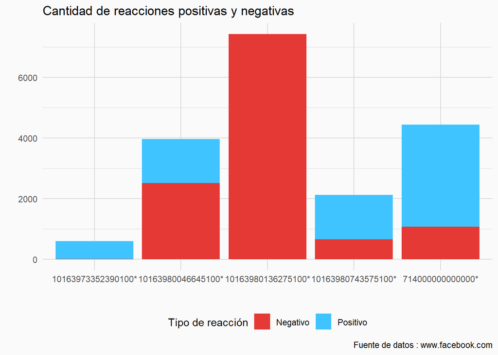

```r
ggplot(sentimientos) +
  geom_bar(aes(x = id.post, y = positivas, fill = "positivas"), stat = "identity", position = "dodge") +
  geom_bar(aes(x = id.post, y = negativas, fill = "negativas"), stat = "identity", position = "dodge") +
  scale_fill_manual(values = c("#E53935", "#40C4FF"), labels = c("Negativo", "Positivo")) +
  theme_minimal(base_family = "Tahoma") +
  labs(title = "Cantidad de reacciones positivas y negativas",
       caption = "Fuente de datos : www.facebook.com",
       y = "",
       x = "",
       fill = "Tipo de reacción") +
  theme(legend.position = "bottom",
        plot.background = element_rect(fill = "gray98", color = "gray98"),
        panel.grid.major = element_line(color = "gray85"),
        panel.grid.minor = element_line(color = "gray85"))
```

Dado que solo son 5 publicaciones, resulta poco practico reflejarlos en un grafico por lo que se procura analizar las reacciones positivas y negativas por publicacion. Para facilidad de lectura se convierte el id de publicacion en un numero de publicacion. En el siguiente grafico.

```r
library(dplyr)
library(lubridate)

publicaciones.reacciones <- inner_join(publicaciones, reacciones[, -1], by = "publicacion")
```

```r
sentimientos <- publicaciones.reacciones %>%
  group_by(publicacion) %>%
  summarise(positivas = sum(megusta + meencanta + meimporta),
            negativas = sum(meenoja + meentristece))

sentimientos
```

```
## # A tibble: 5 x 3
##   publicacion positivas negativas
##         <int>     <int>     <int>
## 1           1      2115       655
## 2           2      2196      7421
## 3           3      3961      2511
## 4           4       596         6
## 5           5      4435      1076
```

[output not shown]

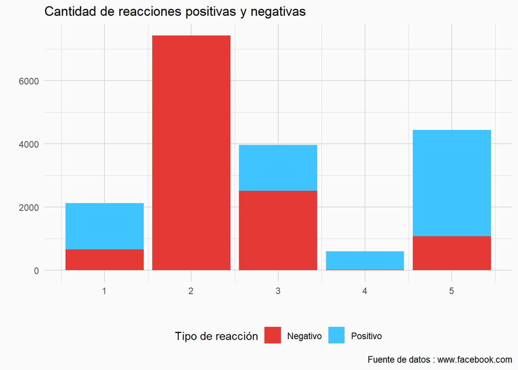

```r
ggplot(sentimientos) +
  geom_bar(aes(x = publicacion, y = positivas, fill = "positivas"), stat = "identity", position = "dodge") +
  geom_bar(aes(x = publicacion, y = negativas, fill = "negativas"), stat = "identity", position = "dodge") +
  scale_fill_manual(values = c("#E53935", "#40C4FF"), labels = c("Negativo", "Positivo")) +
  theme_minimal(base_family = "Tahoma") +
  labs(title = "Cantidad de reacciones positivas y negativas",
       caption = "Fuente de datos : www.facebook.com",
       y = "",
       x = "",
       fill = "Tipo de reacción") +
  theme(legend.position = "bottom",
        plot.background = element_rect(fill = "gray98", color = "gray98"),
        panel.grid.major = element_line(color = "gray85"),
        panel.grid.minor = element_line(color = "gray85"))
```

2. Realice un an´alisis de sentimientos utilizando los comentarios.

```r
comentarios <- read.table(file = "C:/Users/rzamoram/OneDrive - Intel Corporation/Documents/Machine Learning/Mineria de Datos I/Tarea 13 y 14/Tarea 13 y 14_Ricardo Zamora Mennigke_msaludcr_comentariostodos.csv", sep = ",", dec = ".", header = T)
comentarios$comentario <- as.character(comentarios$comentario,ordered = TRUE)
str(comentarios)
```

```
## 'data.frame':    1060 obs. of  7 variables:
##  $ id.pagina  : Factor w/ 2 levels "4.87E+11","id.pagina": 1 1 1 1 1 1 1 1 1 1 ...
##  $ id.post    : Factor w/ 5 levels "10163973352390100*",..: 4 4 4 4 4 4 4 4 4 4 ...
##  $ usuario.id : Factor w/ 87 levels "1.00E+14","alex.loria.1257",..: 14 81 26 NA 6 25 7 45 20 NA ...
##  $ usuario    : Factor w/ 105 levels "ديانا راميريز",..: 48 105 76 NA 9 33 12 86 1 NA ...
##  $ comentario : chr  "En el link de distritos sale el de ayer, que curiosamente la información de Geo tecnología es diferente al cuad"| __truncated__ "Es increíble q un Cantón como Bagaces con solo 10 casos y lo tengan en alerta naranja. Cuál es el negocio del a"| __truncated__ "Q tanto se asusta…
##  $ publicacion: int  1 1 1 1 1 1 1 1 1 1 ...
##  $ X          : Factor w/ 2 levels ""," la población ni cuenta ser hubiera dado que \\\"tenían \\\" el virus\"": 1 1 1 1 1 1 1 1 1 1 ...
```

```r
com <- comentarios$comentario
com <- str_squish(com)
head(com)
```

```
## [1] "En el link de distritos sale el de ayer, que curiosamente la información de Geo tecnología es diferente al cuadro de ayer comparativo de la página. Más que todo el de San Ramón de Alajuela, los números son diferentes. En la página dice 22 casos activos, y el de cantones por GEO dice 56."
## [2] "Es increíble q un Cantón como Bagaces con solo 10 casos y lo tengan en alerta naranja. Cuál es el negocio del albergue en Guayabo?"
## [3] "Q tanto se asusta el ministro de los casos si la culpa la tienen ellos también xq de un principio no cerró todo completamente ya estuviéramos bien pero no a medias todo"
## [4] "Berrí Chest"
## [5] "El de distritos es igual al de ayer! Donde está actualizado?"
## [6] "Y los extranjeros qué 1250 aumentan cada dia de 65 a 85"
```

```r
library(readr)
negativas <- read_file("C:/Users/rzamoram/OneDrive - Intel Corporation/Documents/Machine Learning/Mineria de Datos I/Tarea 13 y 14//PalabrasNegativas.csv", locale = locale(encoding = "Windows-1252")) %>% str_split("\n")
negativas <- negativas[[1]]
positivas <- read_file("C:/Users/rzamoram/OneDrive - Intel Corporation/Documents/Machine Learning/Mineria de Datos I/Tarea 13 y 14//PalabrasPositivas.csv", locale = locale(encoding = "Windows-1252")) %>% str_split("\n")
positivas <- positivas[[1]]
```

```r
com <- str_to_lower(com)
com <- str_remove_all(com, "[[:punct:]]")
head(com)
```

```
## [1] "en el link de distritos sale el de ayer que curiosamente la información de geo tecnología es diferente al cuadro de ayer comparativo de la página más que todo el de san ramón de alajuela los números son diferentes en la página dice 22 casos activos y el de cantones por geo dice 56"
## [2] "es increíble q un cantón como bagaces con solo 10 casos y lo tengan en alerta naranja cuál es el negocio del albergue en guayabo"
## [3] "q tanto se asusta el ministro de los casos si la culpa la tienen ellos también xq de un principio no cerró todo completamente ya estuviéramos bien pero no a medias todo"
## [4] "berrí chest"
## [5] "el de distritos es igual al de ayer donde está actualizado"
## [6] "y los extranjeros qué 1250 aumentan cada dia de 65 a 85"
```

```r
sentimental.score <- function(text, positive.words, negative.words) {
  # Inicio de la función
  sentimental.score <-  lapply(text,
  function(text, positive.words, negative.words) {
    # Separamos el texto en palabras independientes
    words = unlist(str_split(text, " "))
    # Conteo de palabras positivas
    positive = !is.na(match(words, positive.words))
    # Conteo de palabras negativas
    negative = !is.na(match(words, negative.words))
    # Diferencia entre palabras positivas y negativas
    score = sum(positive) - sum(negative)
    # Se retorna el texto,puntaje y la fecha de publicación
    out <- list(text = text, score =  ifelse(score > 0,"Positivo",ifelse(score == 0, "Neutral", "Negativo")))
    return(out)
  }, positive.words, negative.words)
  # Se convierte a un data.frame y se da formato a las columnas.
  out <- data.frame(matrix(unlist(sentimental.score),ncol = 2,byrow = T),stringsAsFactors = F)
  colnames(out) <- c("text", "score")
  return(out)
  # Fin de la función
}
```

```r
score <- sentimental.score(com, positivas, negativas)
head(score$score)
```

```
## [1] "Neutral" "Neutral" "Neutral" "Neutral" "Neutral" "Neutral"
```

```r
opinion <- score %>% group_by(score) %>% summarise(n = n())
opinion
```

```
## # A tibble: 1 x 2
##   score       n
##   <chr>   <int>
## 1 Neutral  1060
```

```r
gear <- read.csv("C:/Users/rzamoram/OneDrive - Intel Corporation/Documents/Machine Learning/Mineria de Datos I/Tarea 13 y 14/Tarea 13 y 14_Ricardo Zamora Mennigke_msaludcr_comentariostodos.csv", sep = ",", dec = ".", header = T)
geartweets <- gear$tweettext

clean.text = function(x)
{
  # tolower
  x = tolower(x)
  # remove rt
  x = gsub("rt", "", x)
  # remove at
  x = gsub("@\\w+", "", x)
  # remove punctuation
  x = gsub("[[:punct:]]", "", x)
  # remove numbers
  x = gsub("[[:digit:]]", "", x)
  # remove links http
  x = gsub("http\\w+", "", x)
  # remove tabs
  x = gsub("[ |\t]{2,}", "", x)
  # remove blank spaces at the beginning
  x = gsub("^ ", "", x)
  # remove blank spaces at the end
  x = gsub(" $", "", x)
  return(x)
}


geartweets = clean.text(geartweets)

neg.words <- read_file("C:/Users/rzamoram/OneDrive - Intel Corporation/Documents/Machine Learning/Mineria de Datos I/Tarea 13 y 14//PalabrasNegativas.csv", locale = locale(encoding = "Windows-1252")) %>% str_split("\n")
neg.words <- neg.words[[1]]
pos.words <- read_file("C:/Users/rzamoram/OneDrive - Intel Corporation/Documents/Machine Learning/Mineria de Datos I/Tarea 13 y 14//PalabrasPositivas.csv", locale = locale(encoding = "Windows-1252")) %>% str_split("\n")
pos.words <- pos.words[[1]]

neg.words = c(neg.words, 'wtf', 'fail')

#Implementing our sentiment scoring algorithm
require(plyr)
require(stringr)
require(stringi)
score.sentiment = function(sentences, pos.words, neg.words, .progress='none')
{


  scores = laply(sentences, function(sentence, pos.words, neg.words) {


    sentence = gsub('[[:punct:]]', '', sentence)
    sentence = gsub('[[:cntrl:]]', '', sentence)
    sentence = gsub('\\d+', '', sentence)

    sentence = tolower(sentence)

    word.list = str_split(sentence, '\\s+')

    words = unlist(word.list)

    pos.matches = match(words, pos.words)
    neg.matches = match(words, neg.words)

    pos.matches = !is.na(pos.matches)
    neg.matches = !is.na(neg.matches)


    score = sum(pos.matches) - sum(neg.matches)

    return(score)
  }, pos.words, neg.words, .progress=.progress )

  scores.df = data.frame(score=scores, text=sentences)
  return(scores.df)
}

sentiment.scores= score.sentiment(com, pos.words, neg.words, .progress='none')
pos.mentioned = subset(sentiment.scores, score > 0)
neu.mentioned = subset(sentiment.scores, score == 0)
neg.mentioned = subset(sentiment.scores, score < 0)

N= nrow(sentiment.scores)
Npos = nrow(pos.mentioned)
Nneu = nrow(neu.mentioned)
Nneg = nrow(neg.mentioned)

dftemp=data.frame(topic=c("Positive", "Negative", "Neutral" ),
                  number=c(Npos, Nneg, Nneu))
```

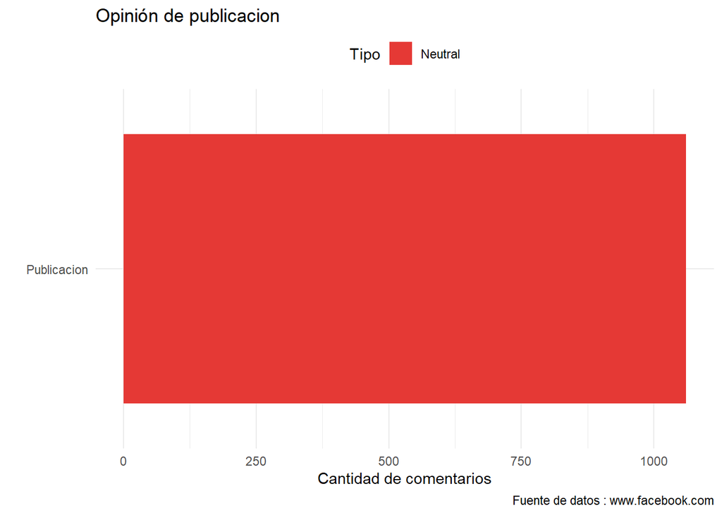

```r
ggplot(opinion, aes("Publicacion", n, fill = score)) +
  geom_bar(stat = "identity",position = "dodge") +
  coord_flip() +
  scale_fill_manual(values = c("#E53935","gray80","#40C4FF")) +
  theme_minimal() +
  labs(title = "Opinión de publicacion",
       x = "", y = "Cantidad de comentarios",
       fill = "Tipo", caption = "Fuente de datos : www.facebook.com") +
  theme(legend.position = "top")
```

3. Con la ayuda de la funci´on paste una todo el texto de los comentarios y luego realice un wordcloud. Aseg´urese de limpiar adecuadamente el texto.

```r
library(tm)
```

```r
library(wordcloud)
#install.packages(readr")
library(readr)

ruta.archivo <- "C:/Users/rzamoram/OneDrive - Intel Corporation/Documents/Machine Learning/Mineria de Datos I/Tarea 13 y 14/Tarea 13 y 14_Ricardo Zamora Mennigke_msaludcr_comentariostodos.csv"
comentar <- readr::read_lines(ruta.archivo, locale = readr::locale(encoding = readr::guess_encoding(ruta.archivo)[1, 1][[1]]))

comentar <- paste0(comentar, collapse = " ")
```

```r
text <- data.frame(doc_id = "Comentarios de publicaciones", text = comentar, stringsAsFactors = F)
str(text)
```

```
## 'data.frame':    1 obs. of  2 variables:
##  $ doc_id: chr "Comentarios de publicaciones"
##  $ text  : chr "id.pagina,id.post,usuario.id,usuario,comentario,publicacion, 4.87E+11,10163980743575100*,comment/replies/,Jairo"| __truncated__
```

```r
ds <- DataframeSource(text)
corpus <- Corpus(ds)
corpus
```

```
## <<SimpleCorpus>>
## Metadata:  corpus specific: 1, document level (indexed): 0
## Content:  documents: 1
```

```r
corpus <- tm_map(corpus, removePunctuation)
corpus <- tm_map(corpus, content_transformer(tolower))
corpus <- tm_map(corpus, removeNumbers)
corpus <- tm_map(corpus, removeWords, stopwords("spanish"))
corpus <- tm_map(corpus, PlainTextDocument)
term_document_matrix <- TermDocumentMatrix(corpus)
term_document_matrix <- as.matrix(term_document_matrix)
term_document_matrix
```

[output not shown]

[output cut: 2175 more lines]

[output not shown]

```r
terms.vector <- sort(rowSums(term_document_matrix), decreasing = TRUE)
term_df <- data.frame(word = names(terms.vector), freq = terms.vector)
head(term_df)
```

```
##                    word freq
## casos             casos  136
## gente             gente   96
## distritos     distritos   88
## extranjeros extranjeros   80
## hoy                 hoy   80
## casa               casa   72
```

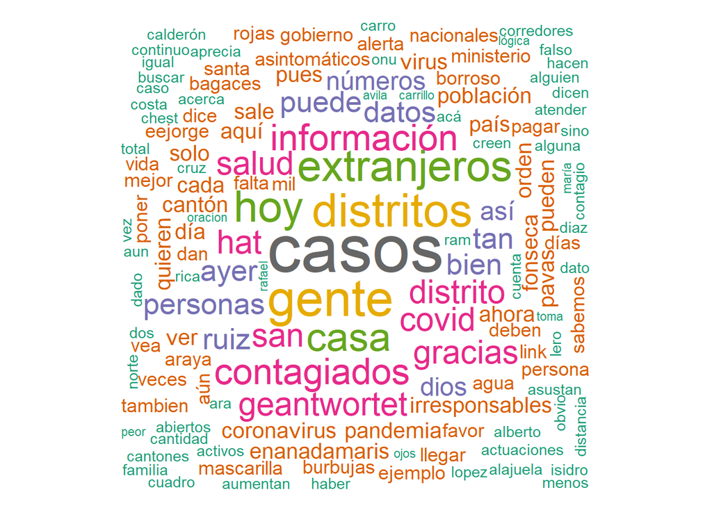

```r
wordcloud(
  words = term_df$word, freq = term_df$freq,scale = c(4,.5), min.freq = 5,
  max.words = 300, random.order = FALSE, rot.per = 0.15,
  colors = brewer.pal(8, "Dark2")
)
```

El wordcloud muestra gran gama de palabras relevantes dentro de los comentarios de las 5 ultimas publicaciones del ministerio de salud en facebook. Las mas relevante parecen ser casos, gente, distritos, extranjeros, contagiados, casa, hoy, covid e informacion.